# Regression Explorations

Franklin Fuchs

# Data Pre-Processing to fit lme4/LmerTest Format

```r
data_cleaned <- read.delim("data_cleaned.txt")

right_eye_df <- data_cleaned[,!grepl("_OS",
                                     colnames(data_cleaned),
                                     ignore.case = FALSE)]

left_eye_df <-  data_cleaned[,!grepl("_OD",
                                     colnames(data_cleaned),
                                     ignore.case = FALSE)]

names(right_eye_df) = gsub(pattern = "_OD",
                           replacement = "",
                           x = names(right_eye_df))

names(left_eye_df) = gsub(pattern = "_OS",
                          replacement = "",
                          x = names(left_eye_df))

right_eye_df$eye <- "right"
left_eye_df$eye <- "left"

# Fix naming inconsistencies
names(left_eye_df)[names(left_eye_df) == 'TO_OR'] <- 'TO_ORT'
names(left_eye_df)[names(left_eye_df) == 'NO_TOS'] <- 'NO_TOT'
names(left_eye_df)[names(left_eye_df) == 'NO_GCL.IPL.'] <- 'NO_.GCL.IPL.'

merged_df <- rbind(right_eye_df,left_eye_df)
```

# Regressions

### Regressions on INL Outcome

```r
CSF_INL = lmer(CSF_INL ~  (1 | IRB) + age + SBP + HbA1c + BUN.Cr + Cholesterol + Ketone + Adiponectin + Leptin + RAGE, data = merged_df)
SI_INL = lmer(SI_INL ~  (1 | IRB) + age + SBP + HbA1c + BUN.Cr + Cholesterol + Ketone + Adiponectin + Leptin + RAGE, data = merged_df)
SO_INL = lmer(SO_INL ~  (1 | IRB) + age + SBP + HbA1c + BUN.Cr + Cholesterol + Ketone + Adiponectin + Leptin + RAGE, data = merged_df)
NI_INL = lmer(NI_INL ~  (1 | IRB) + age + SBP + HbA1c + BUN.Cr + Cholesterol + Ketone + Adiponectin + Leptin + RAGE, data = merged_df)
NO_INL = lmer(NO_INL ~  (1 | IRB) + age + SBP + HbA1c + BUN.Cr + Cholesterol + Ketone + Adiponectin + Leptin + RAGE, data = merged_df)
II_INL = lmer(II_INL ~  (1 | IRB) + age + SBP + HbA1c + BUN.Cr + Cholesterol + Ketone + Adiponectin + Leptin + RAGE, data = merged_df)
IO_INL = lmer(IO_INL ~  (1 | IRB) + age + SBP + HbA1c + BUN.Cr + Cholesterol + Ketone + Adiponectin + Leptin + RAGE, data = merged_df)
TI_INL = lmer(TI_INL ~  (1 | IRB) + age + SBP + HbA1c + BUN.Cr + Cholesterol + Ketone + Adiponectin + Leptin + RAGE, data = merged_df)
TO_INL = lmer(TO_INL ~  (1 | IRB) + age + SBP + HbA1c + BUN.Cr + Cholesterol + Ketone + Adiponectin + Leptin + RAGE, data = merged_df)
```

### Regressions on ORT Outcome

```r
CSF_ORT = lmer(CSF_ORT ~  (1 | IRB) + age + SBP + HbA1c + BUN.Cr + Cholesterol + Ketone + Adiponectin + Leptin + RAGE, data = merged_df)
```

```
## boundary (singular) fit: see help('isSingular')
```

```r
SI_ORT = lmer(SI_ORT ~  (1 | IRB) + age + SBP + HbA1c + BUN.Cr + Cholesterol + Ketone + Adiponectin + Leptin + RAGE, data = merged_df)
SO_ORT = lmer(SO_ORT ~  (1 | IRB) + age + SBP + HbA1c + BUN.Cr + Cholesterol + Ketone + Adiponectin + Leptin + RAGE, data = merged_df)
NI_ORT = lmer(NI_ORT ~  (1 | IRB) + age + SBP + HbA1c + BUN.Cr + Cholesterol + Ketone + Adiponectin + Leptin + RAGE, data = merged_df)
NO_ORT = lmer(NO_ORT ~  (1 | IRB) + age + SBP + HbA1c + BUN.Cr + Cholesterol + Ketone + Adiponectin + Leptin + RAGE, data = merged_df)
II_ORT = lmer(II_ORT ~  (1 | IRB) + age + SBP + HbA1c + BUN.Cr + Cholesterol + Ketone + Adiponectin + Leptin + RAGE, data = merged_df)
IO_ORT = lmer(IO_ORT ~  (1 | IRB) + age + SBP + HbA1c + BUN.Cr + Cholesterol + Ketone + Adiponectin + Leptin + RAGE, data = merged_df)
TI_ORT = lmer(TI_ORT ~  (1 | IRB) + age + SBP + HbA1c + BUN.Cr + Cholesterol + Ketone + Adiponectin + Leptin + RAGE, data = merged_df)
TO_ORT = lmer(TO_ORT ~  (1 | IRB) + age + SBP + HbA1c + BUN.Cr + Cholesterol + Ketone + Adiponectin + Leptin + RAGE, data = merged_df)
```

### Regressions on TOT Outcome

```r
CSF_TOT = lmer(CSF_TOT ~  (1 | IRB) + age + SBP + HbA1c + BUN.Cr + Cholesterol + Ketone + Adiponectin + Leptin + RAGE, data = merged_df)
SI_TOT = lmer(SI_TOT ~  (1 | IRB) + age + SBP + HbA1c + BUN.Cr + Cholesterol + Ketone + Adiponectin + Leptin + RAGE, data = merged_df)
SO_TOT = lmer(SO_TOT ~  (1 | IRB) + age + SBP + HbA1c + BUN.Cr + Cholesterol + Ketone + Adiponectin + Leptin + RAGE, data = merged_df)
NI_TOT = lmer(NI_TOT ~  (1 | IRB) + age + SBP + HbA1c + BUN.Cr + Cholesterol + Ketone + Adiponectin + Leptin + RAGE, data = merged_df)
NO_TOT = lmer(NO_TOT ~  (1 | IRB) + age + SBP + HbA1c + BUN.Cr + Cholesterol + Ketone + Adiponectin + Leptin + RAGE, data = merged_df)
II_TOT = lmer(II_TOT ~  (1 | IRB) + age + SBP + HbA1c + BUN.Cr + Cholesterol + Ketone + Adiponectin + Leptin + RAGE, data = merged_df)
IO_TOT = lmer(IO_TOT ~  (1 | IRB) + age + SBP + HbA1c + BUN.Cr + Cholesterol + Ketone + Adiponectin + Leptin + RAGE, data = merged_df)
TI_TOT = lmer(TI_TOT ~  (1 | IRB) + age + SBP + HbA1c + BUN.Cr + Cholesterol + Ketone + Adiponectin + Leptin + RAGE, data = merged_df)
TO_TOT = lmer(TO_TOT ~  (1 | IRB) + age + SBP + HbA1c + BUN.Cr + Cholesterol + Ketone + Adiponectin + Leptin + RAGE, data = merged_df)
```

# Results

**Interpretation**: In preliminary analysis with bonferroni correction and 36 regressions, HBA1c and Adinopectin seem statistically significant, but only at the $\alpha=0.05$ level, not at the bonferroni corrected alpha level. Making two adjustments by selecting only the TOT sum layer (having thus only 9 regressions) and choosing the less conservative FDR correction yields no significant predictors, although not correcting at all yields cholesterol, Adiponectin, and Leptin to be significant at the $\alpha=0.05$ level for several regions for TOT.

**Next Steps and questions:** Would it be better to consider variable selection to yield a better outcome, so that predictors are possibly better methodologically selected (after we removed correlated predictors of course)? Is there any way of increasing the sample size here, or having more patient data available? We should stick with FDR correction since it is less conservative.

### INL Table

- ’*’ => $\alpha = 0.05$
- ’**’ => $\alpha = 0.01$
- ’***’ => $\alpha = 0.05 / 36$

```r
tab_model(CSF_INL, SI_INL, SO_INL,
          NI_INL, NO_INL, II_INL,
          IO_INL, TI_INL, TO_INL,
          show.ci = FALSE,
          show.p = TRUE,
           p.style = "numeric_stars",
          p.threshold = c(0.05, 0.01, 0.05/36))
```

CSF_INL

SI_INL

SO_INL

NI_INL

NO_INL

II_INL

IO_INL

TI_INL

TO_INL

Predictors

Estimates

p

Estimates

p

Estimates

p

Estimates

p

Estimates

p

Estimates

p

Estimates

p

Estimates

p

Estimates

p

(Intercept)

12.15

0.579

47.10 **

**0.005**

31.06 ***

**<0.001**

41.38 *

**0.020**

29.35 **

**0.003**

43.29 **

**0.004**

30.04 ***

**0.001**

36.82 *

**0.011**

23.27 **

**0.004**

age

0.11

0.567

-0.05

0.749

0.03

0.699

-0.00

0.978

0.06

0.465

-0.04

0.775

0.02

0.740

-0.08

0.495

0.04

0.577

SBP

-0.03

0.604

-0.00

0.967

-0.01

0.749

-0.02

0.697

0.01

0.746

-0.01

0.761

-0.01

0.707

0.01

0.803

0.01

0.699

HbA1c

0.70

0.489

0.28

0.701

0.43

0.257

0.51

0.519

0.40

0.362

0.55

0.413

0.23

0.543

0.81

0.216

0.80 *

**0.027**

BUN Cr

-0.40

0.132

-0.13

0.489

-0.16

0.116

-0.18

0.397

-0.17

0.156

-0.19

0.266

-0.13

0.196

-0.17

0.323

-0.18

0.062

Cholesterol

0.04

0.280

-0.01

0.739

-0.00

0.898

0.00

0.873

0.00

0.827

0.01

0.561

0.01

0.507

0.02

0.398

0.02

0.099

Ketone

-6.40

0.160

0.16

0.962

-0.66

0.700

1.89

0.600

0.10

0.958

4.62

0.126

0.07

0.969

-1.10

0.706

0.22

0.889

Adiponectin

0.00

0.991

-0.09

0.328

0.02

0.655

-0.11

0.278

-0.06

0.302

-0.13

0.111

-0.01

0.860

-0.06

0.467

0.02

0.588

Leptin

-0.05

0.467

-0.00

0.968

-0.01

0.779

0.01

0.802

-0.03

0.260

-0.02

0.589

-0.02

0.438

-0.04

0.315

-0.02

0.426

RAGE

0.24

0.185

0.07

0.614

-0.09

0.168

0.13

0.356

-0.08

0.301

0.01

0.919

-0.05

0.454

0.12

0.315

-0.07

0.299

Random Effects

σ<sup>2</sup>

11.64

3.34

1.48

4.80

2.80

5.25

1.62

4.39

1.44

τ<sub>00</sub>

31.36 <sub>IRB</sub>

18.72 <sub>IRB</sub>

4.61 <sub>IRB</sub>

21.03 <sub>IRB</sub>

5.70 <sub>IRB</sub>

13.63 <sub>IRB</sub>

4.43 <sub>IRB</sub>

13.22 <sub>IRB</sub>

3.94 <sub>IRB</sub>

ICC

0.73

0.85

0.76

0.81

0.67

0.72

0.73

0.75

0.73

N

40 <sub>IRB</sub>

40 <sub>IRB</sub>

40 <sub>IRB</sub>

39 <sub>IRB</sub>

39 <sub>IRB</sub>

40 <sub>IRB</sub>

40 <sub>IRB</sub>

40 <sub>IRB</sub>

40 <sub>IRB</sub>

Observations

75

74

74

71

71

74

74

74

74

Marginal R<sup>2</sup> / Conditional R<sup>2</sup>

0.146 / 0.769

0.075 / 0.860

0.117 / 0.786

0.102 / 0.833

0.122 / 0.711

0.177 / 0.771

0.073 / 0.752

0.170 / 0.793

0.182 / 0.781

- p<0.05 ** p<0.01 *** p<0.001388889

### ORT Table

- ’*’ => $\alpha = 0.05$
- ’**’ => $\alpha = 0.01$
- ’***’ => $\alpha = 0.05 / 36$

```r
tab_model(CSF_ORT, SI_ORT, SO_ORT,
          NI_ORT, NO_ORT, II_ORT,
          IO_ORT, TI_ORT, TO_ORT,
          show.ci = FALSE,
          show.p = TRUE,
           p.style = "numeric_stars",
          p.threshold = c(0.05, 0.01, 0.05/36))
```

CSF_ORT

SI_ORT

SO_ORT

NI_ORT

NO_ORT

II_ORT

IO_ORT

TI_ORT

TO_ORT

Predictors

Estimates

p

Estimates

p

Estimates

p

Estimates

p

Estimates

p

Estimates

p

Estimates

p

Estimates

p

Estimates

p

(Intercept)

94.32

0.324

55.99

0.059

60.16 *

**0.030**

61.63

0.057

88.22

0.054

46.79

0.159

-7.99

0.844

59.79

0.063

59.43 *

**0.038**

age

0.21

0.794

0.48

0.063

0.23

0.340

0.46

0.105

0.20

0.611

0.51

0.085

0.56

0.110

0.45

0.111

0.15

0.555

SBP

-0.18

0.412

0.01

0.889

0.06

0.371

0.04

0.560

-0.02

0.851

0.02

0.764

0.04

0.681

0.03

0.632

0.07

0.299

HbA1c

-0.17

0.968

1.44

0.284

1.28

0.308

1.52

0.300

-0.12

0.953

2.07

0.174

1.29

0.485

1.53

0.296

1.30

0.316

BUN Cr

-0.18

0.876

-0.32

0.366

-0.41

0.209

-0.34

0.379

-0.01

0.980

-0.27

0.492

0.56

0.247

-0.36

0.344

-0.39

0.259

Cholesterol

0.15

0.314

0.10 *

**0.038**

0.04

0.408

0.10

0.058

-0.02

0.736

0.11 *

**0.037**

0.15 *

**0.021**

0.11 *

**0.038**

0.05

0.305

Ketone

-19.56

0.310

-8.20

0.179

-4.28

0.448

-9.74

0.143

-4.13

0.655

-10.49

0.128

-4.93

0.546

-6.31

0.339

-3.52

0.548

Adiponectin

-0.30

0.570

0.18

0.284

0.28

0.070

-0.04

0.841

-0.22

0.407

0.02

0.926

0.03

0.898

0.13

0.481

0.32 *

**0.045**

Leptin

-0.08

0.783

-0.04

0.642

0.03

0.718

-0.12

0.219

0.13

0.357

-0.08

0.429

0.15

0.234

-0.07

0.447

0.06

0.508

RAGE

0.06

0.939

-0.05

0.829

0.12

0.584

-0.04

0.881

0.05

0.900

-0.01

0.959

0.17

0.594

-0.20

0.433

0.08

0.713

Random Effects

σ<sup>2</sup>

1333.96

15.57

12.37

16.56

168.12

14.44

211.48

8.77

9.35

τ<sub>00</sub>

0.00 <sub>IRB</sub>

58.95 <sub>IRB</sub>

51.47 <sub>IRB</sub>

70.50 <sub>IRB</sub>

70.24 <sub>IRB</sub>

77.75 <sub>IRB</sub>

14.38 <sub>IRB</sub>

74.54 <sub>IRB</sub>

57.67 <sub>IRB</sub>

ICC

0.79

0.81

0.81

0.29

0.84

0.06

0.89

0.86

N

40 <sub>IRB</sub>

40 <sub>IRB</sub>

40 <sub>IRB</sub>

39 <sub>IRB</sub>

39 <sub>IRB</sub>

40 <sub>IRB</sub>

40 <sub>IRB</sub>

40 <sub>IRB</sub>

40 <sub>IRB</sub>

Observations

75

74

74

71

72

74

74

74

74

Marginal R<sup>2</sup> / Conditional R<sup>2</sup>

0.035 / NA

0.183 / 0.829

0.145 / 0.834

0.167 / 0.841

0.056 / 0.334

0.169 / 0.870

0.154 / 0.208

0.172 / 0.913

0.162 / 0.883

- p<0.05 ** p<0.01 *** p<0.001388889

### TOT Table (using FDR correction)

```r
tab_model(CSF_TOT, SI_TOT, SO_TOT,
          NI_TOT, NO_TOT, II_TOT,
          IO_TOT, TI_TOT, TO_TOT,
          show.ci = FALSE,
          show.p = TRUE,
          p.style = "numeric_stars",
          p.adjust = c("fdr"))
```

CSF_TOT

SI_TOT

SO_TOT

NI_TOT

NO_TOT

II_TOT

IO_TOT

TI_TOT

TO_TOT

Predictors

Estimates

p

Estimates

p

Estimates

p

Estimates

p

Estimates

p

Estimates

p

Estimates

p

Estimates

p

Estimates

p

(Intercept)

196.13

0.183

302.34 ***

**<0.001**

272.55 ***

**<0.001**

315.40 ***

**<0.001**

299.49 ***

**<0.001**

276.56 ***

**<0.001**

249.39 ***

**<0.001**

251.26 ***

**<0.001**

226.35 ***

**<0.001**

age

0.43

0.842

0.00

0.992

0.12

0.761

-0.11

0.872

-0.10

0.840

0.26

0.675

0.11

0.909

0.21

0.709

0.15

0.707

SBP

-0.06

0.842

0.09

0.556

0.08

0.584

0.07

0.850

0.17

0.452

0.10

0.647

0.11

0.654

0.14

0.326

0.12

0.535

HbA1c

3.57

0.667

2.90

0.367

2.49

0.404

2.47

0.559

1.78

0.658

3.79

0.335

1.99

0.655

4.57

0.140

4.21

0.179

BUN Cr

-1.25

0.530

-0.71

0.367

-0.40

0.584

-0.87

0.491

-0.59

0.610

-0.94

0.335

-0.22

0.909

-1.34

0.108

-0.99

0.205

Cholesterol

0.33

0.183

0.10

0.367

-0.03

0.696

0.12

0.491

-0.04

0.757

0.13

0.335

-0.00

0.986

0.19

0.086

0.06

0.541

Ketone

-35.68

0.219

-11.96

0.367

-11.04

0.404

-12.30

0.559

-11.50

0.606

-9.90

0.647

-12.41

0.597

-13.27

0.326

-8.32

0.541

Adiponectin

0.10

0.842

0.31

0.367

0.59

0.116

0.08

0.872

0.43

0.452

0.07

0.835

0.58

0.232

0.34

0.326

0.69

0.053

Leptin

-0.37

0.463

-0.39

0.056

-0.21

0.404

-0.36

0.187

-0.35

0.163

-0.42

0.074

-0.20

0.597

-0.43

0.054

-0.14

0.540

RAGE

0.20

0.842

-0.10

0.901

-0.43

0.404

0.07

0.872

-0.28

0.658

-0.23

0.675

-0.09

0.909

-0.17

0.709

-0.21

0.646

Random Effects

σ<sup>2</sup>

132.41

33.50

44.88

42.53

27.56

57.07

42.00

28.22

58.30

τ<sub>00</sub>

599.36 <sub>IRB</sub>

171.15 <sub>IRB</sub>

136.72 <sub>IRB</sub>

219.36 <sub>IRB</sub>

210.94 <sub>IRB</sub>

215.22 <sub>IRB</sub>

178.70 <sub>IRB</sub>

216.67 <sub>IRB</sub>

140.61 <sub>IRB</sub>

ICC

0.82

0.84

0.75

0.84

0.88

0.79

0.81

0.88

0.71

N

40 <sub>IRB</sub>

40 <sub>IRB</sub>

40 <sub>IRB</sub>

39 <sub>IRB</sub>

39 <sub>IRB</sub>

40 <sub>IRB</sub>

40 <sub>IRB</sub>

40 <sub>IRB</sub>

40 <sub>IRB</sub>

Observations

75

74

74

71

71

74

74

74

74

Marginal R<sup>2</sup> / Conditional R<sup>2</sup>

0.207 / 0.856

0.230 / 0.874

0.207 / 0.804

0.202 / 0.870

0.193 / 0.907

0.194 / 0.831

0.159 / 0.840

0.306 / 0.920

0.223 / 0.772

- p<0.05 ** p<0.01 *** p<0.001

### INL Effect Size Plots

- ’*’ => $\alpha = 0.05$
- ’**’ => $\alpha = 0.01$
- ’***’ => $\alpha = 0.05 / 36$

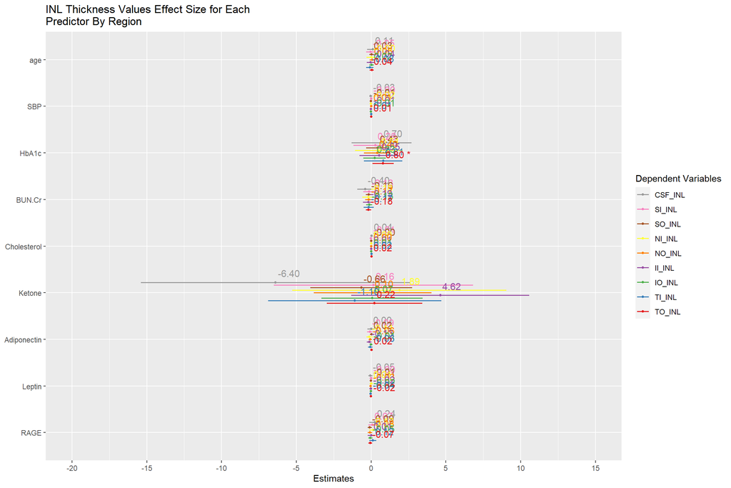

```r
plot_models(title = "INL Thickness Values Effect Size for Each Predictor By Region",
          CSF_INL, SI_INL, SO_INL,
          NI_INL, NO_INL, II_INL,
          IO_INL, TI_INL, TO_INL,
          dot.size = 1,
          spacing = 0.5,
          show.values = TRUE,
          p.threshold = c(0.05, 0.01, 0.05/36))
```

- ’*’ => $\alpha = 0.05$
- ’**’ => $\alpha = 0.01$
- ’***’ => $\alpha = 0.05 / 36$

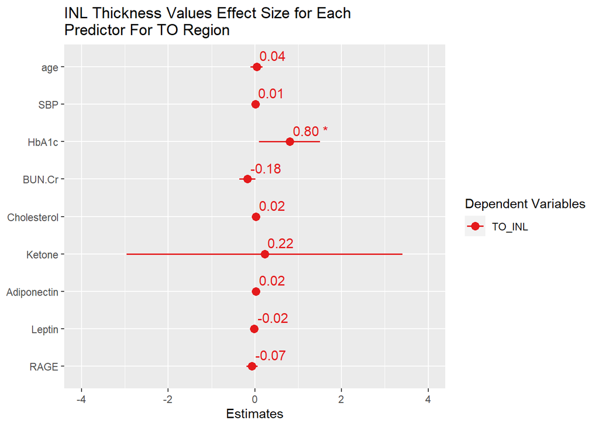

```r
plot_models(title = "INL Thickness Values Effect Size for Each Predictor For TO Region",           TO_INL,
          show.values = TRUE,
          p.threshold = c(0.05, 0.01, 0.05/36))
```

### ORT Effect Size Plots

- ’*’ => $\alpha = 0.05$
- ’**’ => $\alpha = 0.01$
- ’***’ => $\alpha = 0.05 / 36$

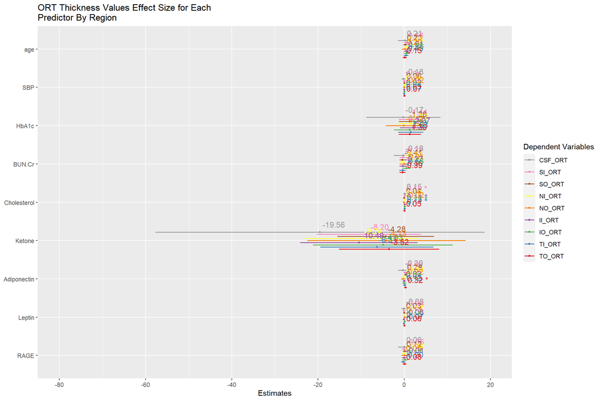

```r
plot_models(title = "ORT Thickness Values Effect Size for Each Predictor By Region",
          CSF_ORT, SI_ORT, SO_ORT,
          NI_ORT, NO_ORT, II_ORT,
          IO_ORT, TI_ORT, TO_ORT,
          dot.size = 1,
          spacing = 0.5,
          show.values = TRUE,
          p.threshold = c(0.05, 0.01, 0.05/36))
```

- ’*’ => $\alpha = 0.05$
- ’**’ => $\alpha = 0.01$
- ’***’ => $\alpha = 0.05 / 36$

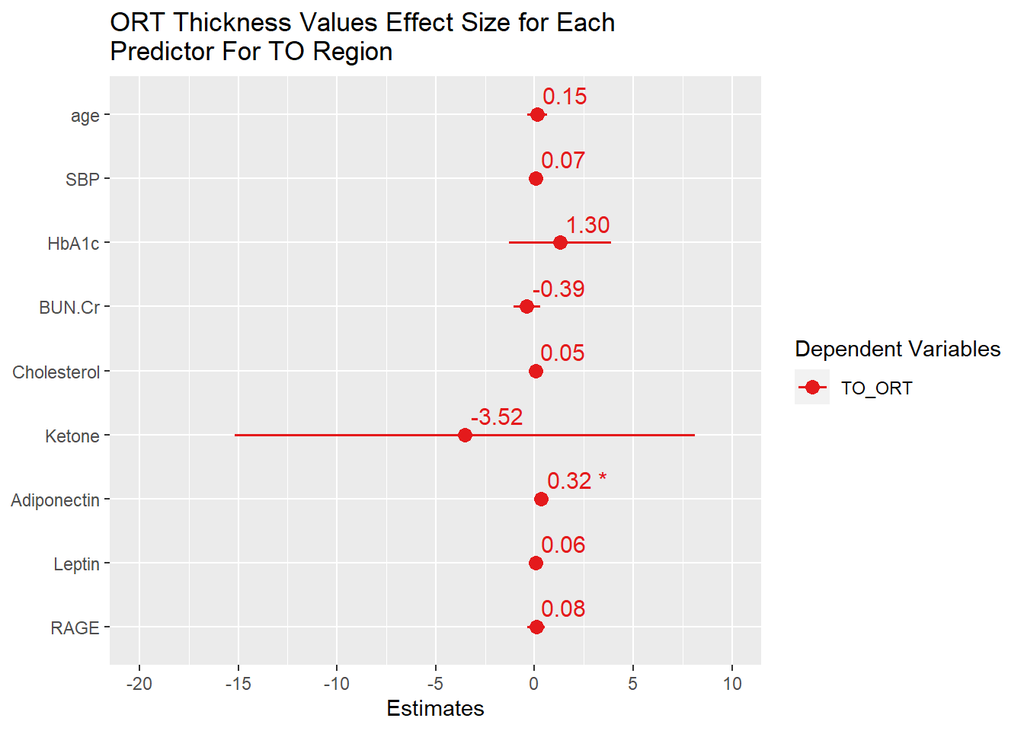

```r
plot_models(title = "ORT Thickness Values Effect Size for Each Predictor For TO Region",
          TO_ORT,
          show.values = TRUE,
          p.threshold = c(0.05, 0.01, 0.05/36))
```

### TOT Effect Size Plots (using FDR correction)

- ’*’ => $\alpha = 0.05$
- ’**’ => $\alpha = 0.05/9$
- ’***’ => $\alpha = 0.001$

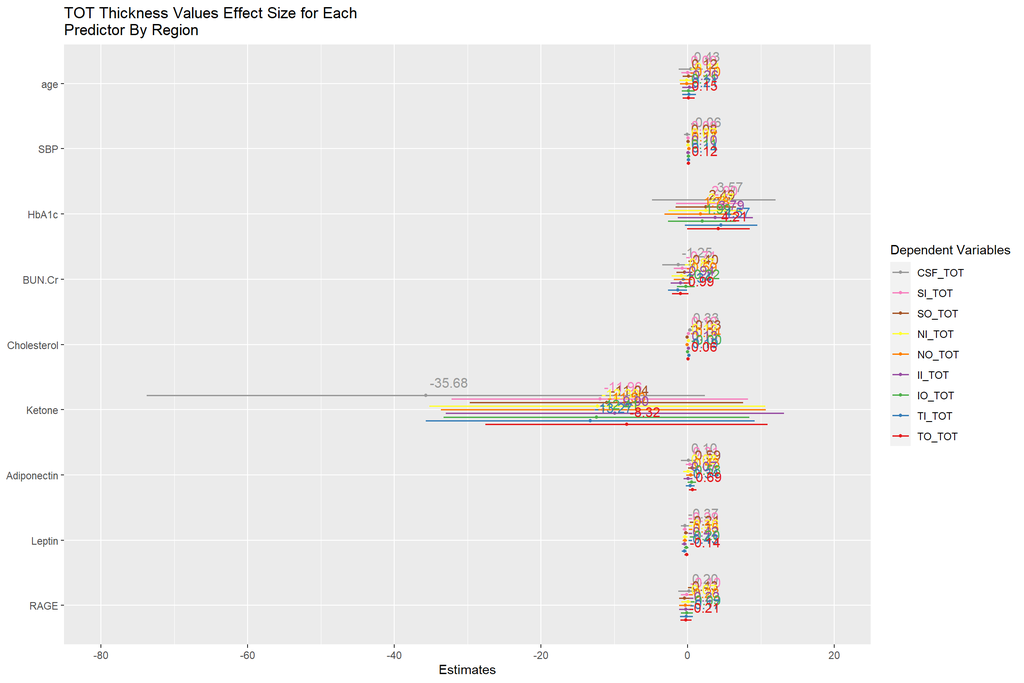

```r
plot_models(title = "TOT Thickness Values Effect Size for Each Predictor By Region",
          CSF_TOT, SI_TOT, SO_TOT,
          NI_TOT, NO_TOT, II_TOT,
          IO_TOT, TI_TOT, TO_TOT,
          dot.size = 1,
          spacing = 0.5,
          show.values = TRUE,
          p.adjust = c("fdr"))
```

- ’*’ => $\alpha = 0.05$
- ’**’ => $\alpha = 0.05/9$
- ’***’ => $\alpha = 0.001$

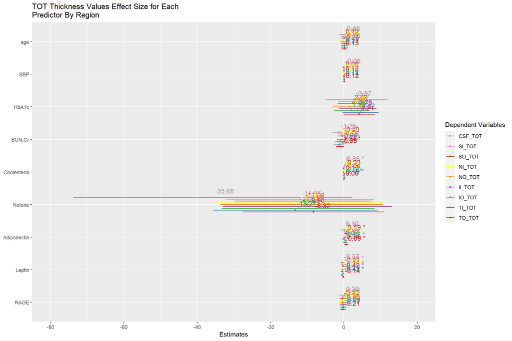

```r
plot_models(title = "TOT Thickness Values Effect Size for Each Predictor By Region",
          CSF_TOT, SI_TOT, SO_TOT,
          NI_TOT, NO_TOT, II_TOT,
          IO_TOT, TI_TOT, TO_TOT,
          dot.size = 1,
          spacing = 0.5,
          show.values = TRUE,
          p.threshold = c(0.05, 0.05/9, 0.001))
```